# **Panorama da inflação**

Os principais índices de inflação do Brasil, apontam em maio de 2011 um avanço da inflação de em média **0.49%**. Com esse resultado, no ano a inflação acumula uma variação média positiva de **3.24%**, e em 12 meses uma variação média acumulada de **7.59%**.

|  | Variação mensal | Variação acumulada no ano | Variação acumulada em 12 meses |
| --- | --- | --- | --- |
| IPCA | 0.47% | 3.71% | 6.55% |
| INPC | 0.57% | 3.48% | 6.44% |
| IGP-M | 0.43% | 2.52% | 9.77% |
| IGP-DI | 0.01% | 2.08% | 9.14% |
| IPA | -0.63% | 0.02% | 0.1% |
| IPC | 0.51% | 2.68% | 6.37% |
| INCC | 2.94% | 4.78% | 8.52% |

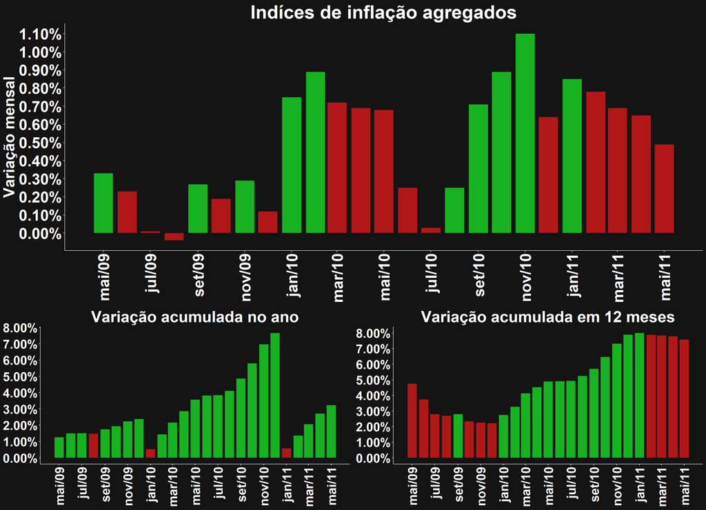

Índices selecionados para a média: IPCA, INPC e IGP-M.

# IPCA

O Indíce de Preços ao Consumidor Amplo (IPCA) variou 0.47% em maio, valor superior ao mesmo período do ano anterior quando apresentou uma taxa de 0.43%. Com esse resultado o indíce acumula no ano uma variação positiva de 3.71%, e em 12 meses uma variação positiva de 6.55%.

|  | 05/2010 | 04/2011 | 05/2011 |
| --- | --- | --- | --- |
| Variação mensal | 0.43% | 0.77% | 0.47% |
| Variação acumulada no ano | 3.09% | 3.23% | 3.71% |
| Variação acumulada em 12 meses | 5.22% | 6.51% | 6.55% |

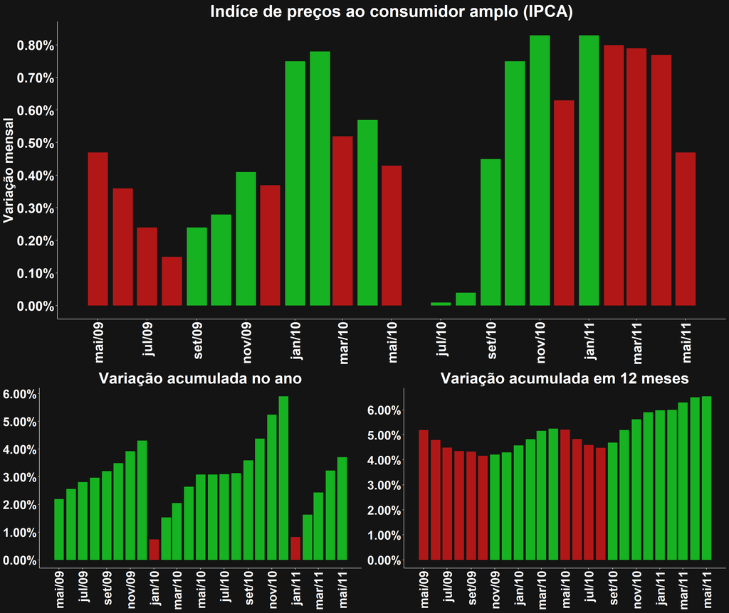

|  | Variação mensal | Variação acumulada no ano | Peso mensal |
| --- | --- | --- | --- |
| Alimentação e bebidas | 0.63% | 3.39% | 23.36% |
| Habitação | 0.97% | 3.17% | 13.08% |
| Artigos de residência | 0.09% | 0.37% | 3.98% |
| Vestuário | 1.19% | 3.07% | 6.76% |
| Transportes | -0.24% | 4.98% | 19.04% |
| Saúde e cuidados pessoais | 0.73% | 2.97% | 10.66% |
| Despesas pessoais | 0.72% | 4.4% | 10.39% |
| Educação | 0.01% | 7.34% | 7.36% |
| Comunicação | 0.15% | 1.1% | 5.37% |

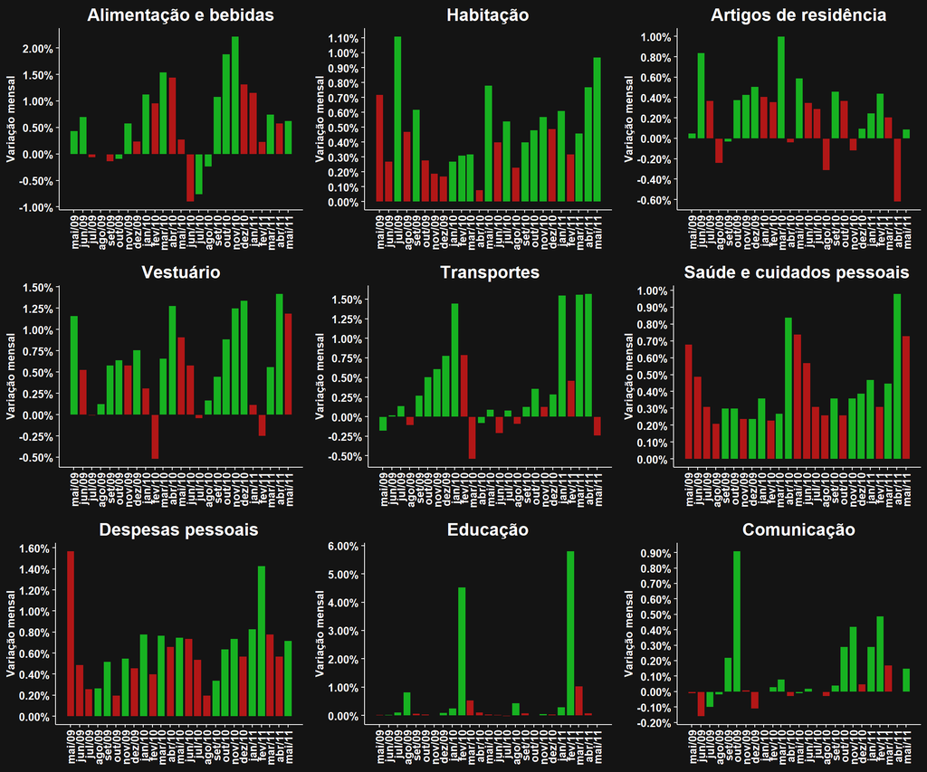

A nível de sub-itens os que mais influenciaram positivamente no resultado em relação ao seu peso foram Empregado doméstico (1.14%%) e Refeição (0.85%%), e negativamente Etanol (-11.34%%) e Passagem aérea (-11.57%%).

|  | Variação mensal | Variação acumulada no ano | Peso mensal |
| --- | --- | --- | --- |
| Taxa de água e esgoto | 2.32% | 4.54% | 1.58% |
| Empregado doméstico | 1.14% | 5.14% | 3.58% |
| Refeição | 0.85% | 5.11% | 4.55% |
| Gasolina | 0.85% | 10.5% | 4.18% |

|  | Variação mensal | Variação acumulada no ano | Peso mensal |
| --- | --- | --- | --- |
| Automóvel usado | -1.26% | -2.06% | 1.1% |
| Etanol | -11.34% | 16.24% | 0.49% |
| Passagem aérea | -11.57% | -2.7% | 0.39% |
| Laranja - pera | -13.16% | 3.22% | 0.18% |

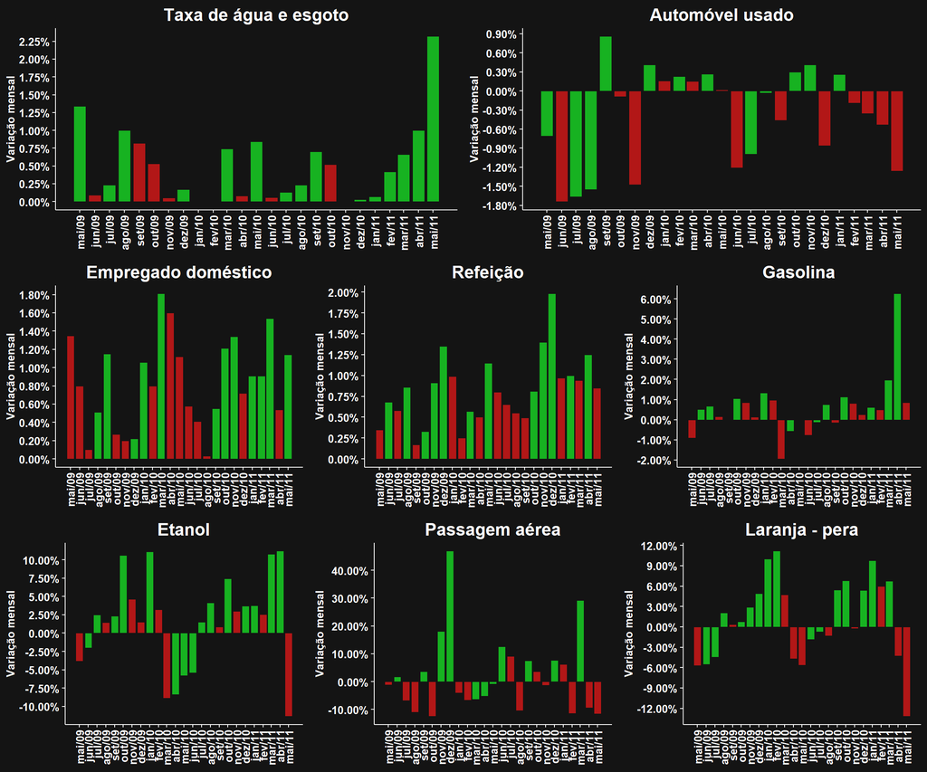

# INPC

O Indíce Nacional de Preços ao Consumidor (INPC) variou 0.57% em maio, valor superior ao mesmo período do ano anterior quando apresentou uma taxa de 0.43%. Com esse resultado o indíce acumula no ano uma variação positiva de 3.48%, e em 12 meses uma variação positiva de 6.44%.

|  | 05/2010 | 04/2011 | 05/2011 |
| --- | --- | --- | --- |
| Variação mensal | 0.43% | 0.72% | 0.57% |
| Variação acumulada no ano | 3.5% | 2.89% | 3.48% |
| Variação acumulada em 12 meses | 5.31% | 6.3% | 6.44% |

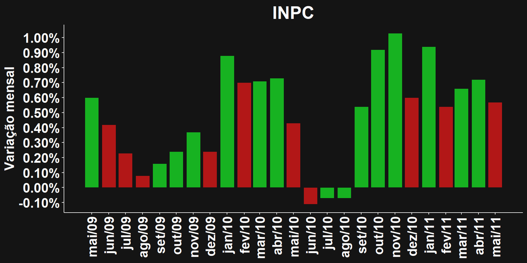

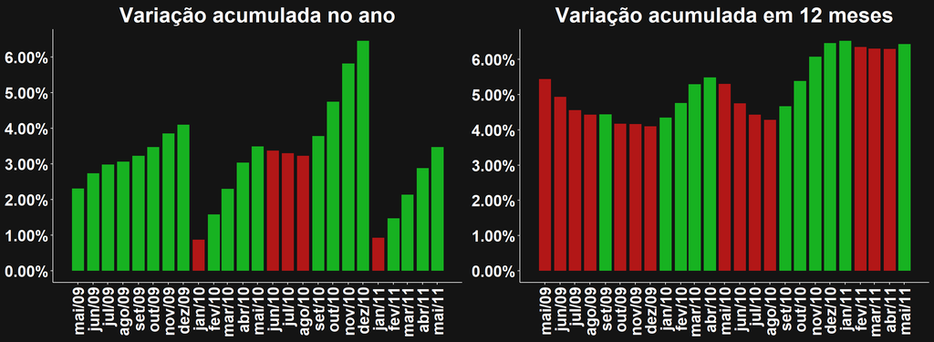

# IGP-M

|  | 05/2010 | 04/2011 | 05/2011 |
| --- | --- | --- | --- |
| Variação mensal | 1.19% | 0.45% | 0.43% |
| Variação acumulada no ano | 4.14% | 2.08% | 2.52% |
| Variação acumulada em 12 meses | 4.18% | 10.6% | 9.77% |

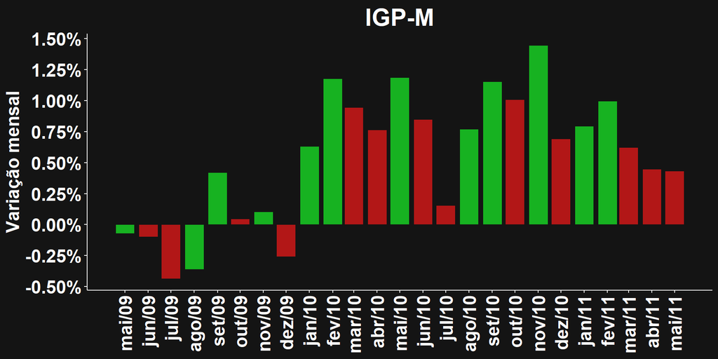

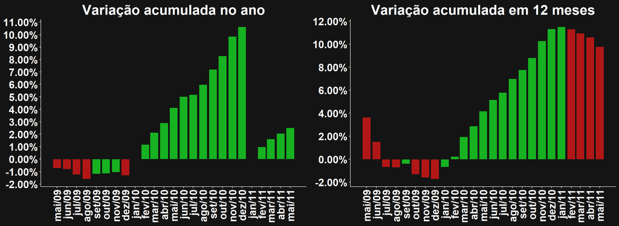

# IGP-DI

|  | 05/2010 | 04/2011 | 05/2011 |
| --- | --- | --- | --- |
| Variação mensal | 1.57% | 0.5% | 0.01% |
| Variação acumulada no ano | 4.07% | 2.08% | 2.08% |
| Variação acumulada em 12 meses | 4.38% | 10.84% | 9.14% |

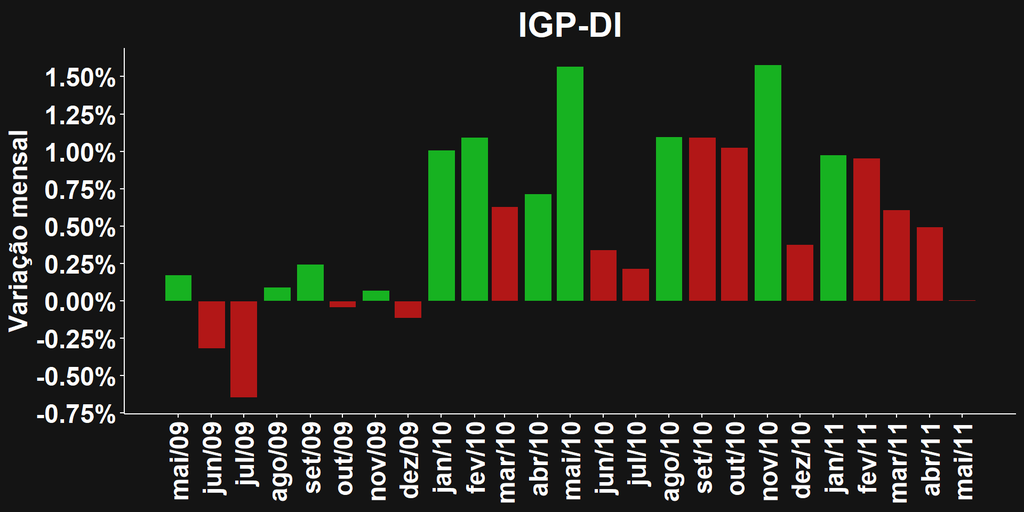

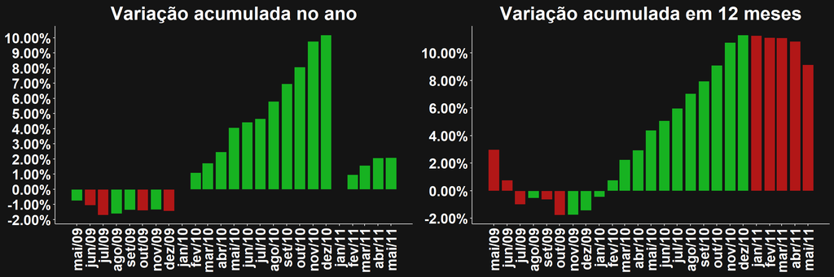

|  | 05/2010 | 04/2011 | 05/2011 |
| --- | --- | --- | --- |
| Variação mensal | 2.06% | 0.24% | -0.63% |
| Variação acumulada no ano | 0.06% | 0.03% | 0.02% |
| Variação acumulada em 12 meses | 0.04% | 0.13% | 0.1% |

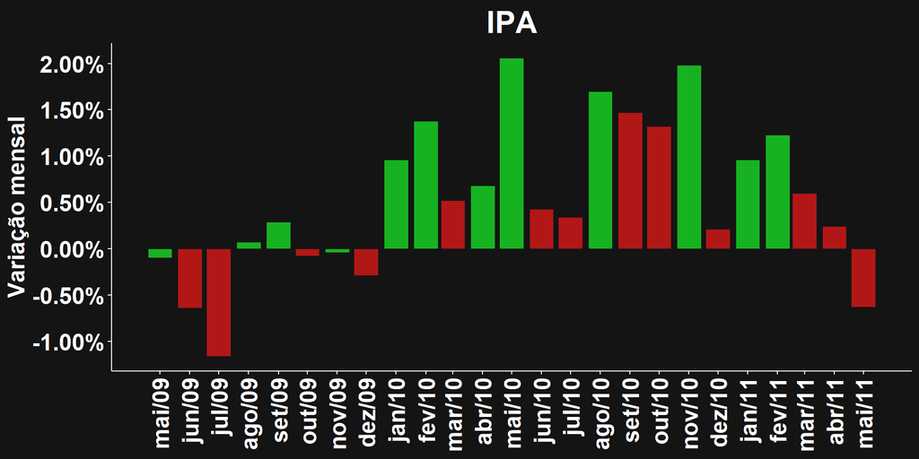

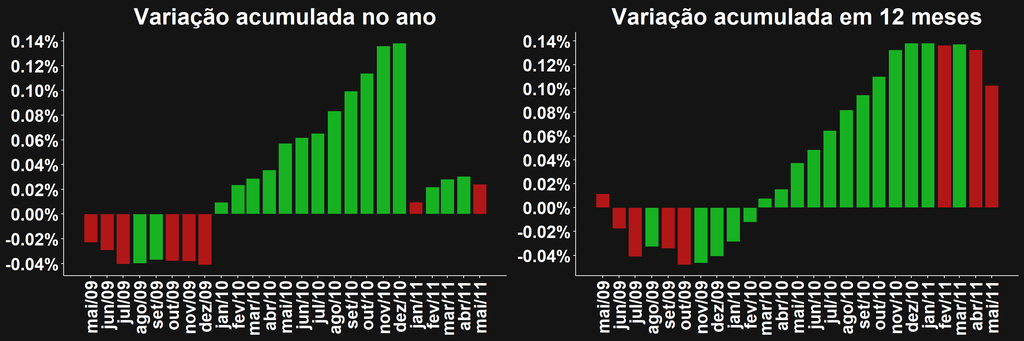

O Indíce de Preços ao Consumidor (IPC), integrante do IGP-DI com peso de 30%, apresentou variação de 0.51% em maio, valor superior ao mesmo período do ano anterior quando apresentou uma taxa de 0.21%. Com esse resultado o indíce acumula no ano uma variação positiva de 2.68%, e em 12 meses uma variação positiva de 6.37%.

|  | 05/2010 | 04/2011 | 05/2011 |
| --- | --- | --- | --- |
| Variação mensal | 0.21% | 0.95% | 0.51% |
| Variação acumulada no ano | 2.53% | 2.16% | 2.68% |
| Variação acumulada em 12 meses | 5.28% | 6.05% | 6.37% |

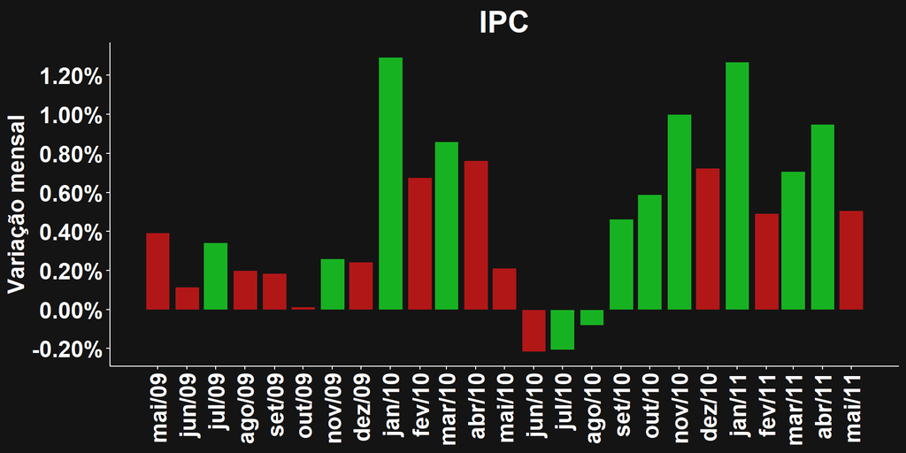

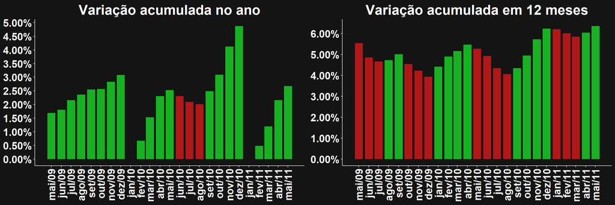

O Indíce Nacional de Custos de Construção (INCC), integrante do IGP-DI com peso de 10%, apresentou variação de 2.94% em maio, valor superior ao mesmo período do ano anterior quando apresentou uma taxa de 1.81%. Com esse resultado o indíce acumula no ano uma variação positiva de 4.78%, e em 12 meses uma variação positiva de 8.52%.

|  | 05/2010 | 04/2011 | 05/2011 |
| --- | --- | --- | --- |
| Variação mensal | 1.81% | 1.06% | 2.94% |
| Variação acumulada no ano | 3.82% | 1.79% | 4.78% |
| Variação acumulada em 12 meses | 6.07% | 7.33% | 8.52% |

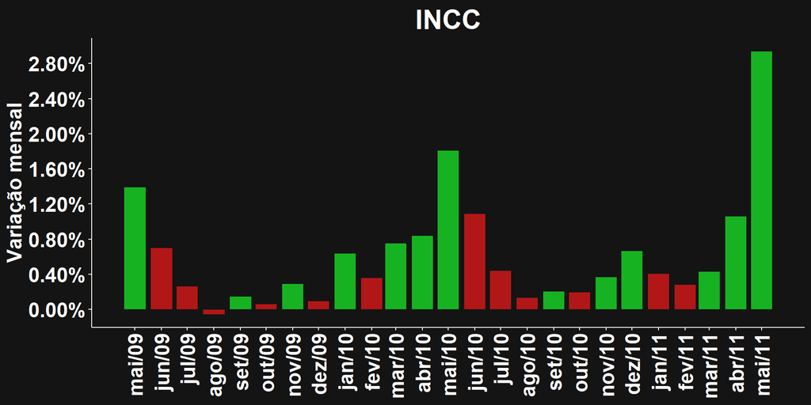

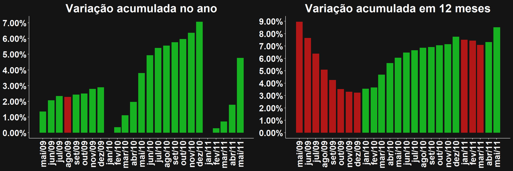

# Estatísticas

As estatísticas descritivas a seguir são feitas com base nos últimos 48 meses, e tem como objetivo possibilitar a avaliação do resultado observado em comparação aos períodos anteriores.

|  | Minimo | 1 Quartil | Mediana | Media | 3 Quartil | Maximo | Desvio Padrão |
| --- | --- | --- | --- | --- | --- | --- | --- |
| IPCA | 0% | 0.28% | 0.47% | 0.46% | 0.58% | 0.83% | 0.23% |
| INPC | -0.11% | 0.28% | 0.5% | 0.48% | 0.67% | 1.03% | 0.29% |
| IGP-M | -0.74% | 0.11% | 0.66% | 0.58% | 1% | 1.98% | 0.64% |
| IGP-DI | -0.84% | 0.07% | 0.55% | 0.58% | 1.09% | 1.89% | 0.65% |
| IPA | -1.46% | -0.09% | 0.52% | 0.61% | 1.33% | 2.29% | 0.94% |
| IPC | -0.21% | 0.21% | 0.47% | 0.46% | 0.71% | 1.29% | 0.35% |
| INCC | -0.26% | 0.27% | 0.44% | 0.64% | 0.85% | 2.94% | 0.61% |

Levando em consideração o desvio padrão de cada indíce, proporcionalmente os que mais se afastaram da média foram o INCC, o IPA e o IGP-DI.

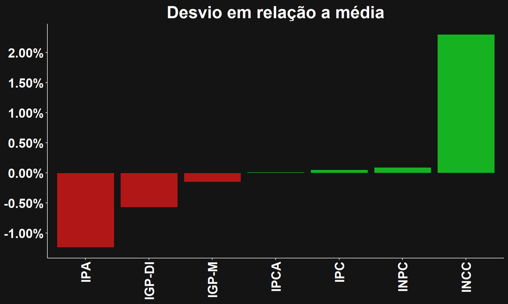

**João Victor Gomes**  
**jvg.santana@gmail.com**  
**[linkedin.com/in/jvictorgomes](https://www.linkedin.com/in/jvictorgomes/)**